# 04. Classification lab

Now we will fit a logistic regression model. We will again use the parsnip package, and we will use logistic_reg() to create a logistic regression model specification.

```r
log_model <-
  logistic_reg() %>%
  set_engine("glm")
```

We can now fit the model like normal. We want to model the Direction of the stock market based on the percentage return from the 5 previous days plus the volume of shares traded. When fitting a classification with parsnip requires that the response variable is a factor. This is the case for the Smarket data set so we don’t need to do adjustments.

```r
log_fit <-
  fit(log_model,
      Direction ~ Lag1 + Lag2 + Lag3 + Lag4 + Lag5 + Volume,
      data = smarket
  )

log_fit
```

```
parsnip model object

Fit time:  0ms

Call:  stats::glm(formula = Direction ~ Lag1 + Lag2 + Lag3 + Lag4 +
    Lag5 + Volume, family = stats::binomial, data = data)

Coefficients:
(Intercept)         Lag1         Lag2         Lag3         Lag4         Lag5
  -0.126000    -0.073074    -0.042301     0.011085     0.009359     0.010313
     Volume
   0.135441

Degrees of Freedom: 1249 Total (i.e. Null);  1243 Residual
Null Deviance:      1731
Residual Deviance: 1728     AIC: 1742
```

```r
log_fit %>% pluck("fit") %>%  summary()
```

```
Call:
stats::glm(formula = Direction ~ Lag1 + Lag2 + Lag3 + Lag4 +
    Lag5 + Volume, family = stats::binomial, data = data)

Deviance Residuals:
   Min      1Q  Median      3Q     Max
-1.446  -1.203   1.065   1.145   1.326

Coefficients:
             Estimate Std. Error z value Pr(>|z|)
(Intercept) -0.126000   0.240736  -0.523    0.601
Lag1        -0.073074   0.050167  -1.457    0.145
Lag2        -0.042301   0.050086  -0.845    0.398
Lag3         0.011085   0.049939   0.222    0.824
Lag4         0.009359   0.049974   0.187    0.851
Lag5         0.010313   0.049511   0.208    0.835
Volume       0.135441   0.158360   0.855    0.392

(Dispersion parameter for binomial family taken to be 1)

    Null deviance: 1731.2  on 1249  degrees of freedom
Residual deviance: 1727.6  on 1243  degrees of freedom
AIC: 1741.6

Number of Fisher Scoring iterations: 3
```

```r
tidy(log_fit)
```

```
# A tibble: 7 x 5
  term        estimate std.error statistic p.value
  <chr>          <dbl>     <dbl>     <dbl>   <dbl>
1 (Intercept) -0.126      0.241     -0.523   0.601
2 Lag1        -0.0731     0.0502    -1.46    0.145
3 Lag2        -0.0423     0.0501    -0.845   0.398
4 Lag3         0.0111     0.0499     0.222   0.824
5 Lag4         0.00936    0.0500     0.187   0.851
6 Lag5         0.0103     0.0495     0.208   0.835
7 Volume       0.135      0.158      0.855   0.392
```

```r
glance(log_fit)
```

```
# A tibble: 1 x 8
  null.deviance df.null logLik   AIC   BIC deviance df.residual  nobs
          <dbl>   <int>  <dbl> <dbl> <dbl>    <dbl>       <int> <int>
1         1731.    1249  -864. 1742. 1778.    1728.        1243  1250
```

A good performing model would ideally have high numbers along the diagonal (up-left to down-right) with small numbers on the off-diagonal. We see here that the model isn’t great, as it tends to predict “Down” as “Up” more often than it should.

```r
predicting <- augment(log_fit, smarket)

conf_mat(predicting,
         truth = Direction,
         estimate = .pred_class)
```

```
          Truth
Prediction Down  Up
      Down  145 141
      Up    457 507
```

```r
predicting %>%
  accuracy(truth = Direction, estimate = .pred_class)
```

```
# A tibble: 1 x 3
  .metric  .estimator .estimate
  <chr>    <chr>          <dbl>
1 accuracy binary         0.522
```

```r
predicting %>%
  roc_auc(truth = Direction, estimate = .pred_Up)
```

```
# A tibble: 1 x 3
  .metric .estimator .estimate
  <chr>   <chr>          <dbl>
1 roc_auc binary         0.461
```

```r
smarket_train <- smarket %>%
  filter(Year != 2005)

smarket_test <- smarket %>%
  filter(Year == 2005)
```

```r
log_fit_train <-
  fit(log_model,
      Direction ~ Lag1 + Lag2 + Lag3 + Lag4 + Lag5 + Volume,
      data = smarket_train
  )

log_fit_train
```

```
parsnip model object

Fit time:  0ms

Call:  stats::glm(formula = Direction ~ Lag1 + Lag2 + Lag3 + Lag4 +
    Lag5 + Volume, family = stats::binomial, data = data)

Coefficients:
(Intercept)         Lag1         Lag2         Lag3         Lag4         Lag5
   0.191213    -0.054178    -0.045805     0.007200     0.006441    -0.004223
     Volume
  -0.116257

Degrees of Freedom: 997 Total (i.e. Null);  991 Residual
Null Deviance:      1383
Residual Deviance: 1381     AIC: 1395
```

```r
log_fit_train %>% pluck("fit") %>%  summary()
```

```
Call:
stats::glm(formula = Direction ~ Lag1 + Lag2 + Lag3 + Lag4 +
    Lag5 + Volume, family = stats::binomial, data = data)

Deviance Residuals:
   Min      1Q  Median      3Q     Max
-1.302  -1.190   1.079   1.160   1.350

Coefficients:
             Estimate Std. Error z value Pr(>|z|)
(Intercept)  0.191213   0.333690   0.573    0.567
Lag1        -0.054178   0.051785  -1.046    0.295
Lag2        -0.045805   0.051797  -0.884    0.377
Lag3         0.007200   0.051644   0.139    0.889
Lag4         0.006441   0.051706   0.125    0.901
Lag5        -0.004223   0.051138  -0.083    0.934
Volume      -0.116257   0.239618  -0.485    0.628

(Dispersion parameter for binomial family taken to be 1)

    Null deviance: 1383.3  on 997  degrees of freedom
Residual deviance: 1381.1  on 991  degrees of freedom
AIC: 1395.1

Number of Fisher Scoring iterations: 3
```

```r
pred2 <- augment(log_fit_train, smarket_test)

conf_mat(pred2,
         truth = Direction,
         estimate = .pred_class)
```

```
          Truth
Prediction Down Up
      Down   77 97
      Up     34 44
```

```r
pred2 %>%
  accuracy(truth = Direction, estimate = .pred_class)
```

```
# A tibble: 1 x 3
  .metric  .estimator .estimate
  <chr>    <chr>          <dbl>
1 accuracy binary         0.480
```

```r
pred2 %>%
  roc_auc(truth = Direction, estimate = .pred_Up)
```

```
# A tibble: 1 x 3
  .metric .estimator .estimate
  <chr>   <chr>          <dbl>
1 roc_auc binary         0.480
```

## Linear Discriminant Analysis

```r
lda_model <-
  discrim_linear() %>%
  set_engine("MASS") %>%
  set_mode("classification")
```

```r
lda_fit <-
  fit(lda_model,
      Direction ~ Lag1 + Lag2,
      data = smarket_train
      )

lda_fit
```

```
parsnip model object

Fit time:  10ms
Call:
lda(Direction ~ Lag1 + Lag2, data = data)

Prior probabilities of groups:
    Down       Up
0.491984 0.508016

Group means:
            Lag1        Lag2
Down  0.04279022  0.03389409
Up   -0.03954635 -0.03132544

Coefficients of linear discriminants:
            LD1
Lag1 -0.6420190
Lag2 -0.5135293
```

```r
predict(lda_fit, smarket_test)
```

```
# A tibble: 252 x 1
   .pred_class
   <fct>
 1 Up
 2 Up
 3 Up
 4 Up
 5 Up
 6 Up
 7 Up
 8 Up
 9 Up
10 Up
# ... with 242 more rows
```

```r
predict(lda_fit, smarket_test, type = "prob")
```

```
# A tibble: 252 x 2
   .pred_Down .pred_Up
        <dbl>    <dbl>
 1      0.490    0.510
 2      0.479    0.521
 3      0.467    0.533
 4      0.474    0.526
 5      0.493    0.507
 6      0.494    0.506
 7      0.495    0.505
 8      0.487    0.513
 9      0.491    0.509
10      0.484    0.516
# ... with 242 more rows
```

```r
lda_pred <- augment(lda_fit, smarket_test)
lda_pred
```

```
# A tibble: 252 x 12
    Year   Lag1   Lag2   Lag3   Lag4   Lag5 Volume  Today Direction .pred_class
   <dbl>  <dbl>  <dbl>  <dbl>  <dbl>  <dbl>  <dbl>  <dbl> <fct>     <fct>
 1  2005 -0.134  0.008 -0.007  0.715 -0.431  0.787 -0.812 Down      Up
 2  2005 -0.812 -0.134  0.008 -0.007  0.715  1.51  -1.17  Down      Up
 3  2005 -1.17  -0.812 -0.134  0.008 -0.007  1.72  -0.363 Down      Up
 4  2005 -0.363 -1.17  -0.812 -0.134  0.008  1.74   0.351 Up        Up
 5  2005  0.351 -0.363 -1.17  -0.812 -0.134  1.57  -0.143 Down      Up
 6  2005 -0.143  0.351 -0.363 -1.17  -0.812  1.48   0.342 Up        Up
 7  2005  0.342 -0.143  0.351 -0.363 -1.17   1.49  -0.61  Down      Up
 8  2005 -0.61   0.342 -0.143  0.351 -0.363  1.49   0.398 Up        Up
 9  2005  0.398 -0.61   0.342 -0.143  0.351  1.56  -0.863 Down      Up
10  2005 -0.863  0.398 -0.61   0.342 -0.143  1.51   0.6   Up        Up
# ... with 242 more rows, and 2 more variables: .pred_Down <dbl>,
#   .pred_Up <dbl>
```

```r
lda_pred %>% conf_mat(truth = Direction, estimate = .pred_class)
```

```
          Truth
Prediction Down  Up
      Down   35  35
      Up     76 106
```

```r
lda_pred %>% accuracy(truth = Direction, estimate = .pred_class)
```

```
# A tibble: 1 x 3
  .metric  .estimator .estimate
  <chr>    <chr>          <dbl>
1 accuracy binary         0.560
```

```r
lda_pred %>% roc_auc(truth = Direction, estimate = .pred_Up)
```

```
# A tibble: 1 x 3
  .metric .estimator .estimate
  <chr>   <chr>          <dbl>
1 roc_auc binary         0.442
```

## K-Nearest Neighbors

```r
knn_model1 <-
  nearest_neighbor(neighbors = 1) %>%
  set_engine("kknn") %>%
  set_mode("classification")

knn_model3 <-
  nearest_neighbor(neighbors = 3) %>%
  set_engine("kknn") %>%
  set_mode("classification")

knn_model5 <-
  nearest_neighbor(neighbors = 5) %>%
  set_engine("kknn") %>%
  set_mode("classification")
```

```r
knn_fit1 <-
  fit(knn_model1,
      Direction ~Lag1 + Lag2,
      data = smarket_train)

knn_fit3 <-
  fit(knn_model3,
      Direction ~Lag1 + Lag2,
      data = smarket_train)

knn_fit5 <-
  fit(knn_model5,
      Direction ~Lag1 + Lag2,
      data = smarket_train)
```

```r
knn_pred1 <-
  augment(knn_fit1, smarket_test)

knn_pred3 <-
  augment(knn_fit3, smarket_test)

knn_pred5 <-
  augment(knn_fit5, smarket_test)
```

```r
knn_pred1 %>%
  conf_mat(
    truth = Direction,
    estimate = .pred_class
    )
```

```
          Truth
Prediction Down Up
      Down   43 58
      Up     68 83
```

```r
knn_pred3 %>%
  conf_mat(
    truth = Direction,
    estimate = .pred_class
    )
```

```
          Truth
Prediction Down Up
      Down   43 58
      Up     68 83
```

```r
knn_pred5 %>%
  conf_mat(
    truth = Direction,
    estimate = .pred_class
    )
```

```
          Truth
Prediction Down Up
      Down   45 57
      Up     66 84
```

```r
knn_pred1 %>% accuracy(truth = Direction, estimate = .pred_class)
```

```
# A tibble: 1 x 3
  .metric  .estimator .estimate
  <chr>    <chr>          <dbl>
1 accuracy binary           0.5
```

```r
knn_pred3 %>% accuracy(truth = Direction, estimate = .pred_class)
```

```
# A tibble: 1 x 3
  .metric  .estimator .estimate
  <chr>    <chr>          <dbl>
1 accuracy binary           0.5
```

```r
knn_pred5 %>% accuracy(truth = Direction, estimate = .pred_class)
```

```
# A tibble: 1 x 3
  .metric  .estimator .estimate
  <chr>    <chr>          <dbl>
1 accuracy binary         0.512
```

```r
knn_pred1 %>% roc_auc(truth = Direction, estimate = .pred_Up)
```

```
# A tibble: 1 x 3
  .metric .estimator .estimate
  <chr>   <chr>          <dbl>
1 roc_auc binary         0.512
```

```r
knn_pred3 %>% roc_auc(truth = Direction, estimate = .pred_Up)
```

```
# A tibble: 1 x 3
  .metric .estimator .estimate
  <chr>   <chr>          <dbl>
1 roc_auc binary         0.486
```

```r
knn_pred5 %>% roc_auc(truth = Direction, estimate = .pred_Up)
```

```
# A tibble: 1 x 3
  .metric .estimator .estimate
  <chr>   <chr>          <dbl>
1 roc_auc binary         0.482
```

### Comapring models

This section is new and not part of ISLR. We have fitted a lot of different models in this lab. And we were able to calculate the performance metrics one by one, but it is not ideal if we want to compare the different models. Below is an example of how you can more conveniently calculate performance metrics for multiple models at the same time.

```r
models <- list(
  "log_reg" = log_fit_train,
  "LDA" = lda_fit,
  "KNN1" = knn_fit1,
  "KNN5" = knn_fit5
  )
```

```r
preds <- imap_dfr(models,
                  augment,
                  new_data = smarket_test,
                  .id = "model")

preds %>%
  dplyr::select(Direction, .pred_class, .pred_Down, .pred_Up)
```

```
# A tibble: 1,008 x 4
   Direction .pred_class .pred_Down .pred_Up
   <fct>     <fct>            <dbl>    <dbl>
 1 Down      Up               0.472    0.528
 2 Down      Up               0.484    0.516
 3 Down      Up               0.477    0.523
 4 Up        Up               0.486    0.514
 5 Down      Down             0.502    0.498
 6 Up        Up               0.499    0.501
 7 Down      Up               0.497    0.503
 8 Up        Up               0.490    0.510
 9 Down      Up               0.496    0.504
10 Up        Up               0.489    0.511
# ... with 998 more rows
```

```r
multi_metric <- metric_set(accuracy, sensitivity, specificity)

preds %>%
  group_by(model) %>%
  multi_metric(truth = Direction, estimate = .pred_class)
```

```
# A tibble: 12 x 4
   model   .metric  .estimator .estimate
   <chr>   <chr>    <chr>          <dbl>
 1 KNN1    accuracy binary         0.5
 2 KNN5    accuracy binary         0.512
 3 LDA     accuracy binary         0.560
 4 log_reg accuracy binary         0.480
 5 KNN1    sens     binary         0.387
 6 KNN5    sens     binary         0.405
 7 LDA     sens     binary         0.315
 8 log_reg sens     binary         0.694
 9 KNN1    spec     binary         0.589
10 KNN5    spec     binary         0.596
11 LDA     spec     binary         0.752
12 log_reg spec     binary         0.312
```

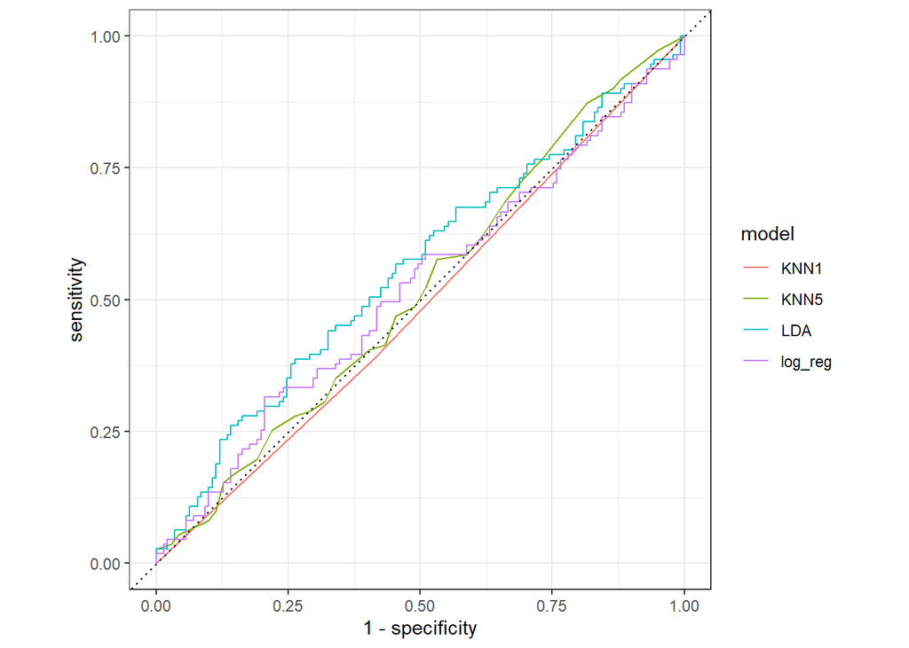

```r
preds %>%
  group_by(model) %>%
  roc_curve(Direction, .pred_Down) %>%
  autoplot()
```

An Introduction to Statistcial Learning https://www.statlearning.com/

ISLR tidymodels Labs https://emilhvitfeldt.github.io/ISLR-tidymodels-labs/linear-regression.html

– END